# Lab4

Marcos Bernier

2022-02-11

# Tasks

## Task1

```r
getwd()
```

```
## [1] "/Users/marcosbernier/Dev/stats/MATH4753BERN0021/labs/lab4"
```

## Task2

```r
ss <- read.csv("SPRUCE.csv")
tail(ss)
```

```
##    BHDiameter Height
## 31       17.7   19.9
## 32       20.7   19.4
## 33       21.0   20.4
## 34       13.3   15.5
## 35       15.9   17.6
## 36       22.9   19.2
```

## Task3

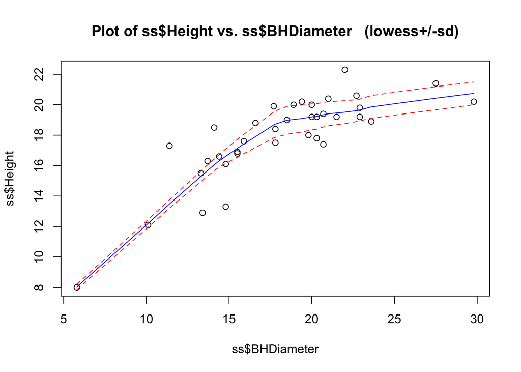

```r
library(s20x)
trendscatter(ss$Height~ss$BHDiameter,f=0.5)
```

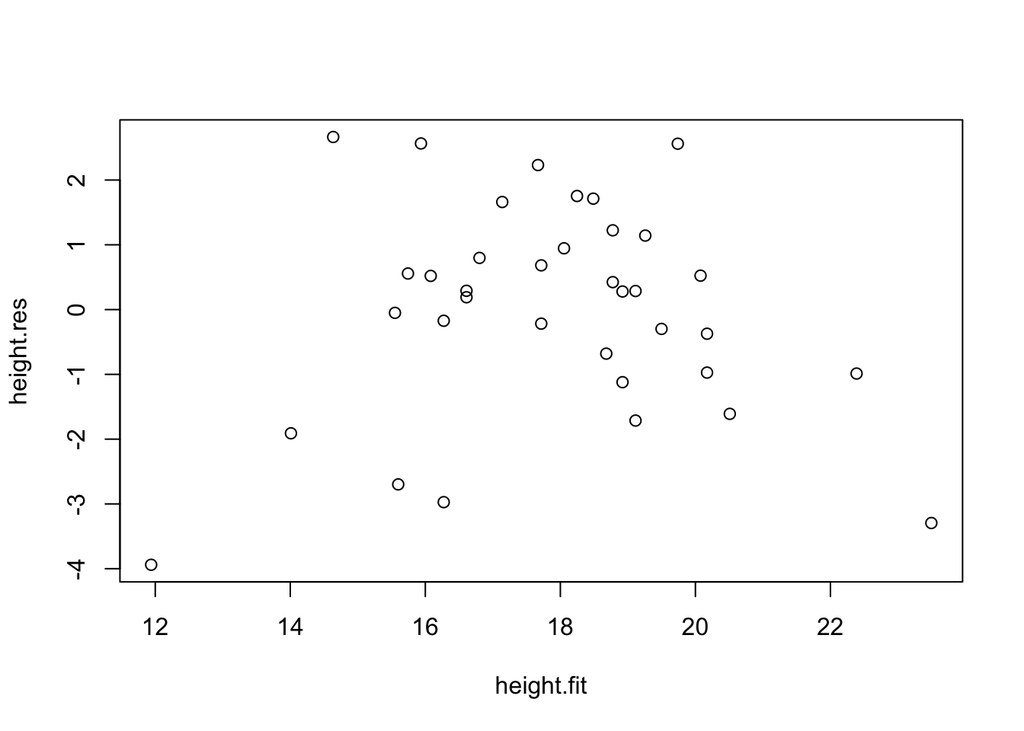

```r
spruce.lm = lm(Height~BHDiameter,data = ss)
height.res = residuals(spruce.lm)
height.fit = fitted(spruce.lm)

plot(height.res~height.fit)
```

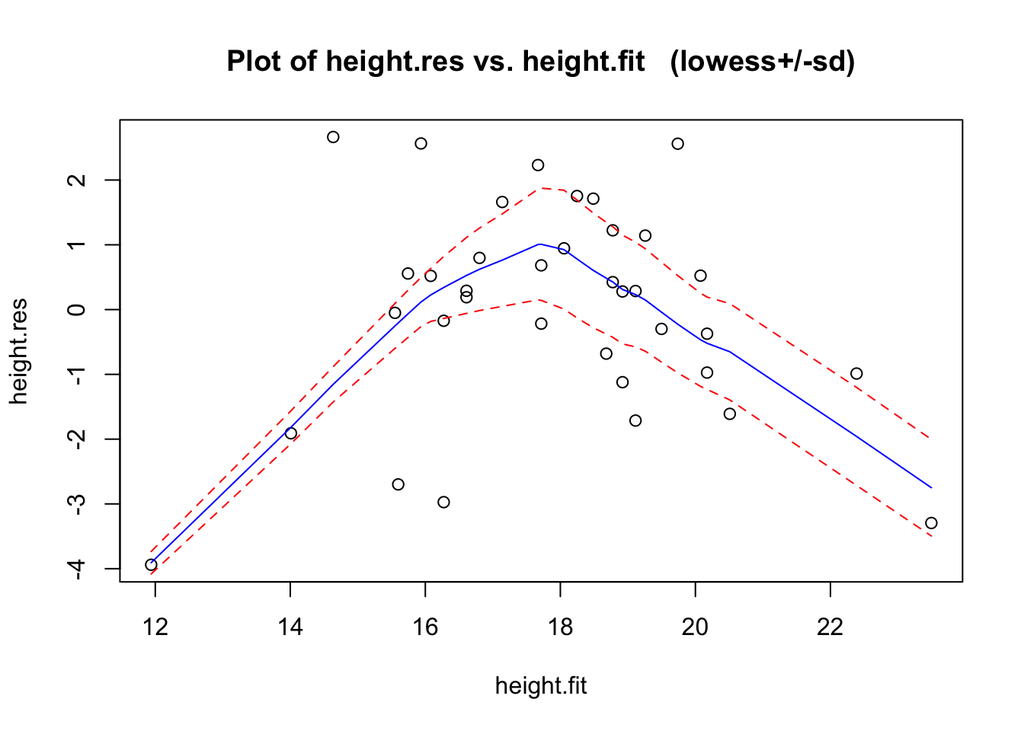

```r
trendscatter(height.res~height.fit)
```

The plot displays a parabolic trend, compared to a more linear (flatlining later) trend in the first plot.

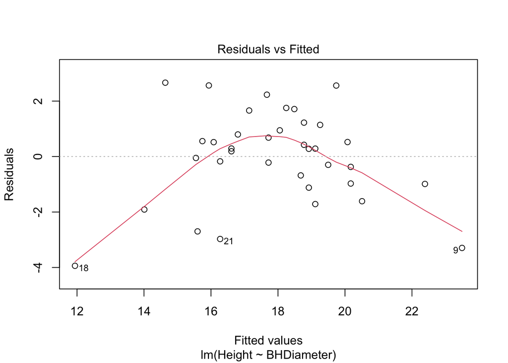

```r
plot(spruce.lm, which =1 )
```

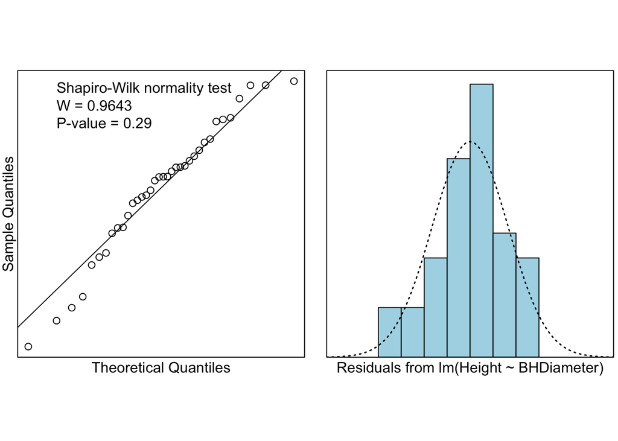

```r
normcheck(spruce.lm, shapiro.wilk = TRUE)
```

The p-value is .29 > 0.05 which means the null hypothesis is accepted and the error is distributed normally

```r
round(mean(height.res,4))
```

```
## [1] 0
```

We shouldn’t use a straighjt line model to describe this data because the actual trend is more quadratic, so we need to figure a better line to fit the data more descriptively.

## Task 4

```r
quad.lm = lm(Height~BHDiameter + I(BHDiameter ^ 2), data = ss)
summary(quad.lm)
```

```
##
## Call:
## lm(formula = Height ~ BHDiameter + I(BHDiameter^2), data = ss)
##
## Residuals:
##     Min      1Q  Median      3Q     Max
## -3.2966 -0.6245 -0.0707  0.7442  3.2541
##
## Coefficients:
##                  Estimate Std. Error t value Pr(>|t|)
## (Intercept)      0.860896   2.205022   0.390 0.698731
## BHDiameter       1.469592   0.243786   6.028 8.88e-07 ***
## I(BHDiameter^2) -0.027457   0.006635  -4.138 0.000227 ***
## ---
## Signif. codes:  0 '***' 0.001 '**' 0.01 '*' 0.05 '.' 0.1 ' ' 1
##
## Residual standard error: 1.382 on 33 degrees of freedom
## Multiple R-squared:  0.7741, Adjusted R-squared:  0.7604
## F-statistic: 56.55 on 2 and 33 DF,  p-value: 2.182e-11
```

```r
coef(quad.lm)
```

```
##     (Intercept)      BHDiameter I(BHDiameter^2)
##      0.86089580      1.46959217     -0.02745726
```

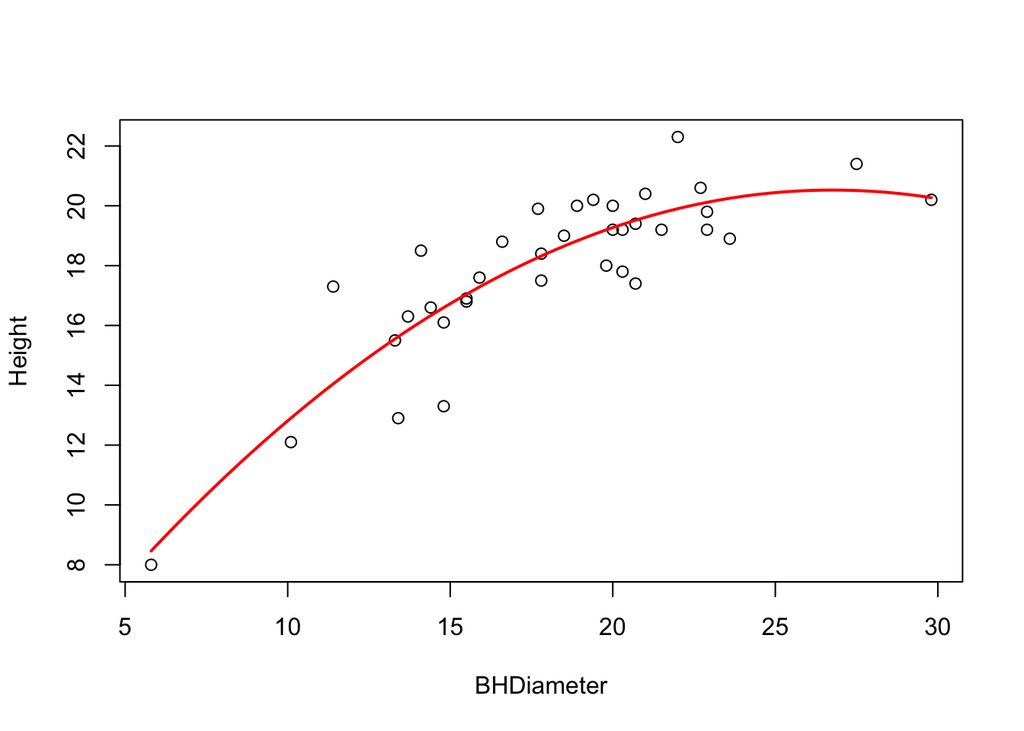

```r
plot(ss)
plottttt = function(x)
{
  quad.lm$coef[1] + quad.lm$coef[2] * x + quad.lm$coef[3] * x^2
}

curve (plottttt, lwd = 2, col = "red", add = TRUE)
```

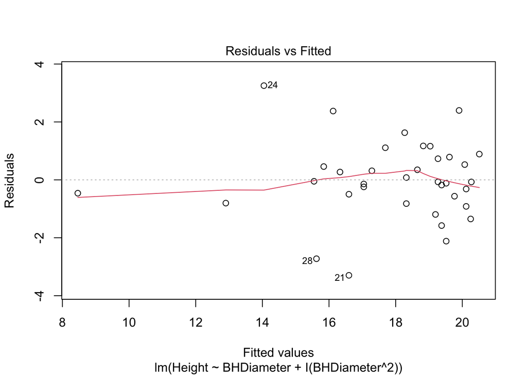

```r
quad.fit = fitted(quad.lm)
plot(quad.lm, which = 1)
```

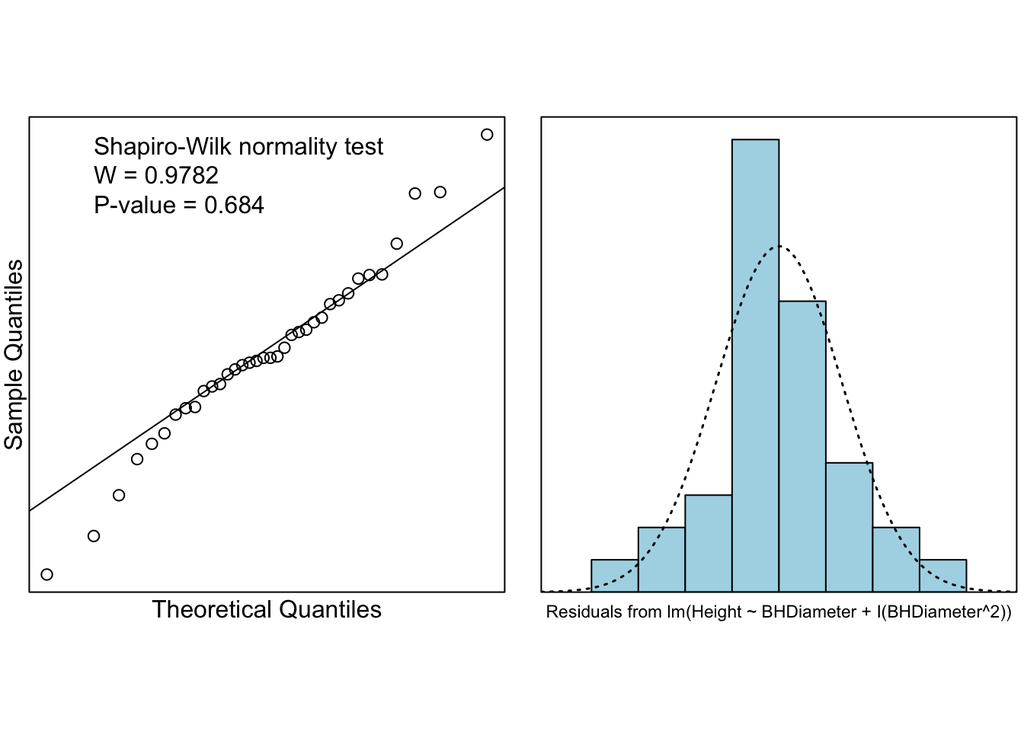

```r
normcheck(quad.lm, shapiro.wilk = TRUE)
```

P value is .684. The null hypothesis accepts this. The model fits better than the previous linear model.

## Task5

```r
summary(quad.lm)
```

```
##
## Call:
## lm(formula = Height ~ BHDiameter + I(BHDiameter^2), data = ss)
##
## Residuals:
##     Min      1Q  Median      3Q     Max
## -3.2966 -0.6245 -0.0707  0.7442  3.2541
##
## Coefficients:
##                  Estimate Std. Error t value Pr(>|t|)
## (Intercept)      0.860896   2.205022   0.390 0.698731
## BHDiameter       1.469592   0.243786   6.028 8.88e-07 ***
## I(BHDiameter^2) -0.027457   0.006635  -4.138 0.000227 ***
## ---
## Signif. codes:  0 '***' 0.001 '**' 0.01 '*' 0.05 '.' 0.1 ' ' 1
##
## Residual standard error: 1.382 on 33 degrees of freedom
## Multiple R-squared:  0.7741, Adjusted R-squared:  0.7604
## F-statistic: 56.55 on 2 and 33 DF,  p-value: 2.182e-11
```

B0hat, B1hat, B2hat = 0.860896, 1.469592, -0.027457

```r
ciReg(quad.lm)
```

```
##                 95 % C.I.lower    95 % C.I.upper
## (Intercept)           -3.62525           5.34705
## BHDiameter             0.97361           1.96558
## I(BHDiameter^2)       -0.04096          -0.01396
```

Y = 0.860896 + 1.46959x - 0.027457x^2

```r
predict(quad.lm, data.frame(BHDiameter = c(15,18,20)))
```

```
##        1        2        3
## 16.72690 18.41740 19.26984
```

```r
predict(spruce.lm, data.frame(BHDiameter = c(15,18,20)))
```

```
##        1        2        3
## 16.36895 17.81338 18.77632
```

The quad.lm predictions are larger than spruce.lm and correctly allign with quadratic growth.

```r
summary(quad.lm)$r.squared
```

```
## [1] 0.7741266
```

R^2 = 0.7741266

```r
summary(spruce.lm)$r.squared
```

```
## [1] 0.6569146
```

R^2 = 0.6569146

```r
summary(quad.lm)$adj.r.squared
```

```
## [1] 0.7604373
```

```r
summary(spruce.lm)$adj.r.squared
```

```
## [1] 0.6468239
```

Adjusted r squared gets higher as a model improves with mopre variables. Quad.lm is higher so it is a better fit.

Multiple r squared does the same thing but it is not dependent on the amount/addition of new variables/data to the models.

Quad.lm best explains the variability in height, The Rsquared and AdjRsqaured values are greatest

```r
anova(spruce.lm)
```

```
## Analysis of Variance Table
##
## Response: Height
##            Df  Sum Sq Mean Sq F value    Pr(>F)
## BHDiameter  1 183.245 183.245  65.101 2.089e-09 ***
## Residuals  34  95.703   2.815
## ---
## Signif. codes:  0 '***' 0.001 '**' 0.01 '*' 0.05 '.' 0.1 ' ' 1
```

```r
anova(quad.lm)
```

```
## Analysis of Variance Table
##
## Response: Height
##                 Df  Sum Sq Mean Sq F value    Pr(>F)
## BHDiameter       1 183.245 183.245  95.975 2.701e-11 ***
## I(BHDiameter^2)  1  32.696  32.696  17.125 0.0002269 ***
## Residuals       33  63.007   1.909
## ---
## Signif. codes:  0 '***' 0.001 '**' 0.01 '*' 0.05 '.' 0.1 ' ' 1
```

```r
anova(spruce.lm, quad.lm)
```

```
## Analysis of Variance Table
##
## Model 1: Height ~ BHDiameter
## Model 2: Height ~ BHDiameter + I(BHDiameter^2)
##   Res.Df    RSS Df Sum of Sq      F    Pr(>F)
## 1     34 95.703
## 2     33 63.007  1    32.696 17.125 0.0002269 ***
## ---
## Signif. codes:  0 '***' 0.001 '**' 0.01 '*' 0.05 '.' 0.1 ' ' 1
```

Quad.lm better fits the data as a model.

```r
height.qfit = fitted(quad.lm)

TSS = with(ss, sum((Height - mean(Height))^2))
MSS = with(ss, sum((height.qfit - mean(Height))^2))
RSS = with(ss, sum((Height - height.qfit)^2))


TSS
```

```
## [1] 278.9475
```

```r
MSS
```

```
## [1] 215.9407
```

```r
RSS
```

```
## [1] 63.00683
```

TSS, MSS, RSS in respective order above. MSS/TSS below.

```r
MSS/TSS
```

```
## [1] 0.7741266
```

## Task 6

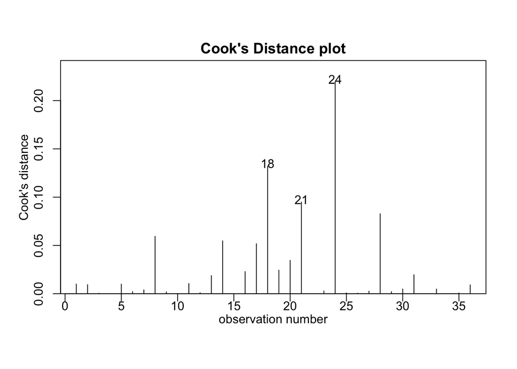

```r
cooks20x(quad.lm)
```

Cooks distance is used to find outliers in variables. The distance is used to identify data points that might negatively affect the model of regression. So if the distance is great, the impact on the model is great. The 24th observation number is the most influential in the data for quad.lm.

```r
quad2.lm = lm(Height~BHDiameter + I(BHDiameter^2), data = ss[-24,])
summary(quad2.lm)
```

```
##
## Call:
## lm(formula = Height ~ BHDiameter + I(BHDiameter^2), data = ss[-24,
##     ])
##
## Residuals:
##      Min       1Q   Median       3Q      Max
## -3.11233 -0.48227  0.01253  0.71727  2.59146
##
## Coefficients:
##                  Estimate Std. Error t value Pr(>|t|)
## (Intercept)     -0.341500   2.068479  -0.165     0.87
## BHDiameter       1.564793   0.226102   6.921 7.78e-08 ***
## I(BHDiameter^2) -0.029242   0.006114  -4.782 3.74e-05 ***
## ---
## Signif. codes:  0 '***' 0.001 '**' 0.01 '*' 0.05 '.' 0.1 ' ' 1
##
## Residual standard error: 1.266 on 32 degrees of freedom
## Multiple R-squared:  0.8159, Adjusted R-squared:  0.8044
## F-statistic: 70.91 on 2 and 32 DF,  p-value: 1.74e-12
```

## Task 7

There are two lines with $x_k$ in common :

$L_1: y = \beta_0 + \beta_1x$ AND

$L_2: y = \beta_0 + \delta + (\beta_1 + \beta_2)x$

We will plug in the point $x_k$ and make the equations set equal to eachother because the share the common point:

$y_k = \beta_0 + \beta_1x_k =\beta_0 + \delta + (\beta_1 + \beta_2)x_k$

$x_k$ can be distributed to the RHS:

$\quad \quad \beta_0 + \beta_1x_k - \beta_0 + \delta + \beta_1x_k + \beta_2x_k$

$\beta_0$ and $\beta_1x$ cancel:

$\quad \quad 0 = \delta + \beta_2 x_k$

$\quad \quad \delta = -\beta_2 x_k$

$L_2 : y = \beta_0 + \delta + (\beta_1 + \beta_2)x$

Substitute the found value for $\delta$:

$L_2 : y = \beta_0 -\beta_2 x_k + (\beta_1 + \beta_2)x$

$\quad\quad y = \beta_0 + \beta_1x + \beta_2(x-x_k)$

This new equations is $L_1$ with $\beta_2(x-x_k)$ appended

$I()$ is 1 when $x > x_k$ and 0 for all other conditions.

Leaving : $y = \beta_0 + \beta_1x + \beta_2(x-x_k)I(x>x_k)$

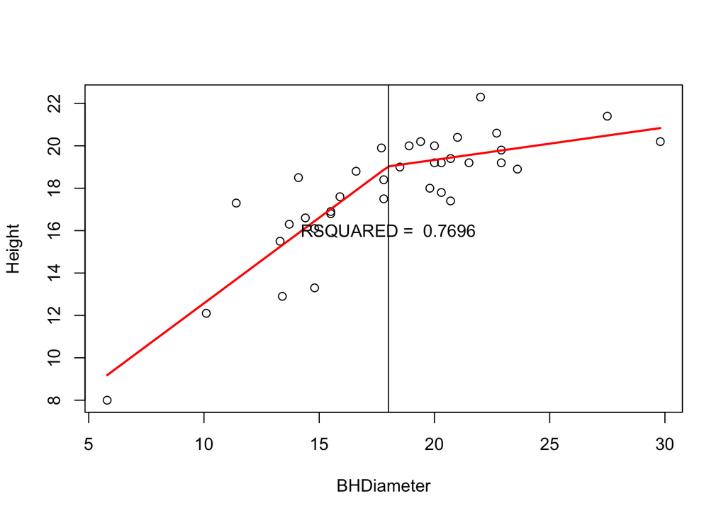

```r
ss2 = within(ss, X <- (BHDiameter-18) * (BHDiameter>18))

plot(ss)
coefadder = function(x, coef)
{
  coef[1] + coef[2] * (x) + coef[3] * (x-18) *(x-18 >0)
}
temp = lm(Height~BHDiameter + X, data = ss2)
temp = summary(temp)
curve(coefadder(x,coef=temp$coefficients[,"Estimate"]), add = TRUE, lwd = 2, col = "red")
text(18,16,paste("RSQUARED = " ,round(temp$r.squared,4)))
abline(v=18)
```

## Task 8

```r
library(MATH4753BERN0021)
print2()
```

```
## [1] 2
```

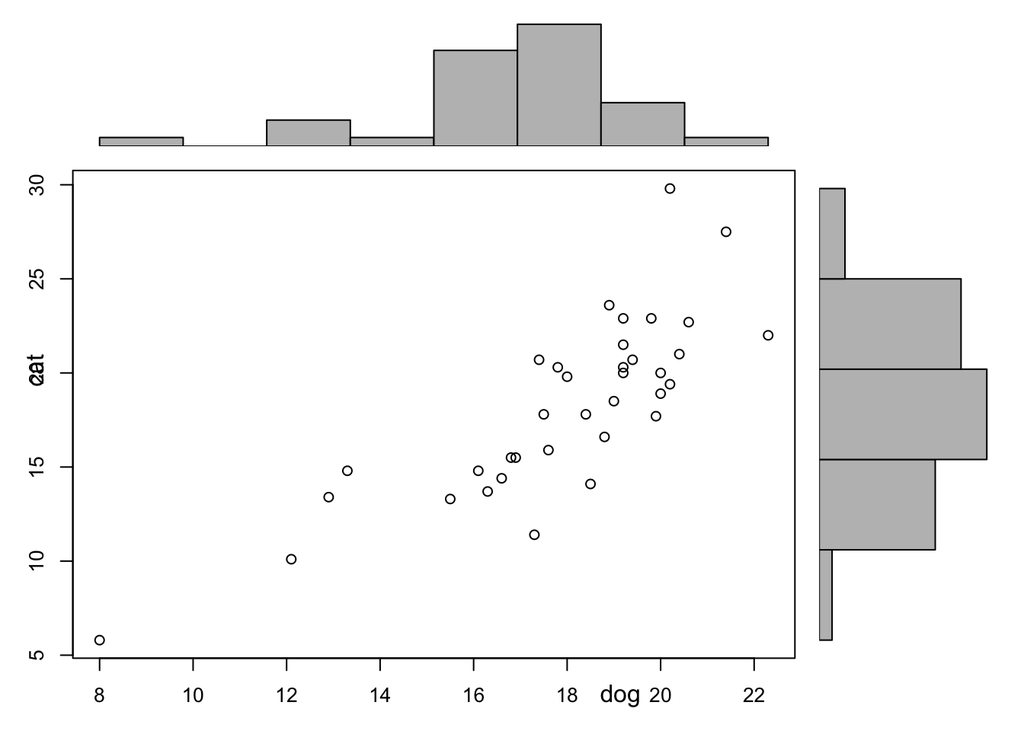

```r
scatterhist(ss$Height,ss$BHDiameter,"dog","cat")
```

I imported two functions here, a function I wrote called print2, and the scatterhist function from lab1. The print2 function simply print 2 to console output. The scatterhist function generates a scatterplot and a histogram appended to the axes accoridng to a set of x and y values! I used the data included in lab4 to run this function. print2 takes no arguments. It just prints 2 :D